# Auswertung v1

01 Oktober 2015

```r
library(pander)
library(plyr)
```

# 1 Datensätze

Die Auswertungen erfolgen für den gesamten Datensatz (**df**) sowie für jedes Kontrolljahr einzeln (**df10 bis df15**). Dabei ist zu beachten, dass 2010 das gesamte Untersuchungsgebiet kontrolliert wurde, da es sich um eine bezahlte Studie handelte; in den Folgejahren wurde das Projekt als rein ehrenamtliches Monitoring weitergeführt, daher konnten aus Zeitgründen nur Teilgebiete untersucht werden.

```r
source("Auswertung/read.R")
```

Einen Überblick über den Umfang der Kontrollen in den einzelnen Jahren geben die Kontrollierten Schläge.

```r
tab.schlag <- with(df, table(schlag, koa))
m.schlag <- as.data.frame.matrix(tab.schlag)
m.schlag <- rbind(m.schlag, Summe=colSums(m.schlag))
m.schlag <- cbind(m.schlag, gesamt=rowSums(m.schlag))
```

```r
Table1 <- pander(
         m.schlag,
         caption="Datensätze pro Schlag",

         digits=0
         )
Table1
```

Datensätze pro Schlag

|  | 10 | 11 | 12 | 13 | 14 | 15 | gesamt |
| --- | --- | --- | --- | --- | --- | --- | --- |
| **bb** | 15 | 17 | 0 | 0 | 9 | 0 | 41 |
| **bk** | 1 | 4 | 0 | 0 | 19 | 0 | 24 |
| **e** | 0 | 0 | 0 | 1 | 5 | 0 | 6 |
| **g** | 8 | 0 | 0 | 6 | 0 | 4 | 18 |
| **hb** | 6 | 0 | 0 | 0 | 0 | 0 | 6 |
| **hk** | 21 | 0 | 0 | 16 | 0 | 27 | 64 |
| **ho** | 9 | 1 | 0 | 8 | 11 | 0 | 29 |
| **hz** | 14 | 3 | 18 | 0 | 2 | 29 | 66 |
| **ki** | 8 | 0 | 1 | 5 | 0 | 7 | 21 |
| **kle** | 4 | 3 | 0 | 0 | 7 | 0 | 14 |
| **klo** | 20 | 19 | 0 | 0 | 20 | 0 | 59 |
| **m** | 31 | 0 | 0 | 35 | 0 | 33 | 99 |
| **rk** | 24 | 0 | 0 | 21 | 0 | 0 | 45 |
| **sg** | 6 | 0 | 5 | 0 | 0 | 6 | 17 |
| **ss** | 2 | 0 | 0 | 13 | 0 | 0 | 15 |
| **Summe** | 169 | 47 | 24 | 105 | 73 | 106 | 524 |

# 2 Welche Arten haben ihre Sommerquartiere im Untersuchungsgebiet?

```r
levels(df$flart)
```

```
##  [1] "0"                     "M.daubentonii"
##  [3] "M.myotis"              "M.mystacinus/brandtii"
##  [5] "M.nattereri"           "Nyc.noctula"
##  [7] "Pip"                   "Pip.nathusii"
##  [9] "Pip.pygmaeus"          "Plec.auritus"
```

Von 2010 bis 2015 wurden acht Arten sowie nicht weiter bestimmte *Pipistrellus*-Arten gefunden:

- Wasserfledermaus (*Myotis daubentonii*)
- Großes Mausohr (*Myotis myotis*)
- Bartfledermäuse (*Myotis mystacinus* oder *Myotis brandtii*)
- Fransenfledermaus (*Myotis nattereri*)
- Großer Abernsegler (*Nyctalus noctula*)
- Rauhautfledermaus (*Pipistrellus nathusii*)
- Mückenfledermaus (*Pipistrellus pygmaeus*)
- Braunes Langohr (*Plecotus auritus*)

```r
tab.art <- with(df, table(flart, koa))
m.art <- as.data.frame.matrix(tab.art)
m.art <- m.art[-1,]
m.art <- rbind(m.art, Summe=colSums(m.art))
m.art <- cbind(m.art, gesamt=rowSums(m.art))
```

```r
Table2 <- pander(
         m.art,
         caption="Quartiere pro Art",
         digits=0,
         split.table=Inf
         )
Table2
```

Quartiere pro Art

|  | 10 | 11 | 12 | 13 | 14 | 15 | gesamt |
| --- | --- | --- | --- | --- | --- | --- | --- |
| **M.daubentonii** | 1 | 6 | 0 | 2 | 1 | 6 | 16 |
| **M.myotis** | 2 | 0 | 0 | 2 | 1 | 0 | 5 |
| **M.mystacinus/brandtii** | 1 | 0 | 0 | 0 | 0 | 0 | 1 |
| **M.nattereri** | 15 | 10 | 2 | 10 | 21 | 16 | 74 |
| **Nyc.noctula** | 1 | 0 | 0 | 0 | 0 | 0 | 1 |
| **Pip** | 0 | 0 | 0 | 1 | 0 | 0 | 1 |
| **Pip.nathusii** | 2 | 0 | 0 | 0 | 0 | 0 | 2 |
| **Pip.pygmaeus** | 0 | 1 | 0 | 1 | 0 | 0 | 2 |
| **Plec.auritus** | 8 | 0 | 0 | 4 | 0 | 1 | 13 |
| **Summe** | 30 | 17 | 2 | 20 | 23 | 23 | 115 |

```r
df.ind.art <- ddply(df, .(koa, flart), summarise, Individuen = sum(flges))
```

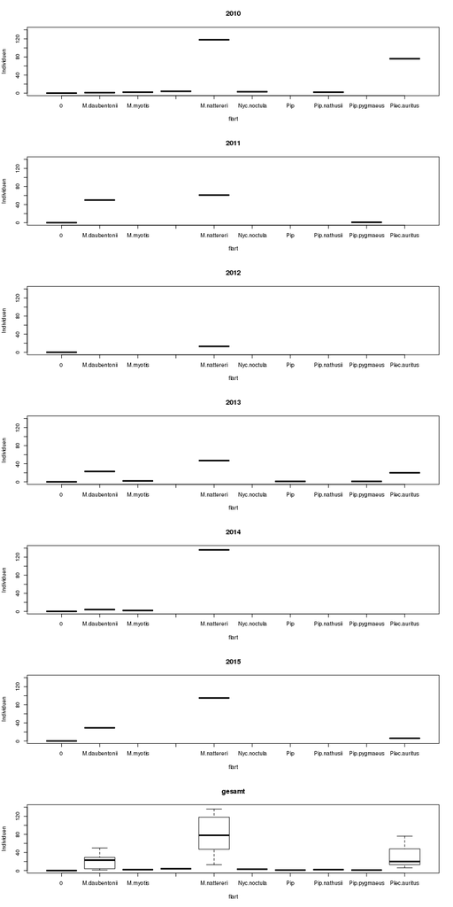

Individuen pro Art

```r
par(mfrow=c(7,1))
for(i in 10:15){
    with(
         subset(df.ind.art, koa == i),
         plot(Individuen ~ flart,
          main=paste0("20", i),
          ylim=c(0,140)
          )
         )
}
with(df.ind.art,
     plot(Individuen ~ flart,
      main="gesamt",
      ylim=c(0,140)
      )
     )
```

Die Wasserfledermaus (**Myotis daubentonii**), die 2010 nur mit einem Individuum beobachtet wurde, scheint weitaus häufiger zu sein. Da die Schwankungen in den Zählergebnissen nicht mit denen in den Gebieten Rotes Kreuz / Mitterbachl, die offenes Wasser bieten, übereinstimmen, ist von einer methodischen Zählungenauigkeit auszugehen. Die Fransenfledermaus (**Myotis nattereri**) ist nach wie vor die dominierende Art im Feilenforst. Leider lässt sich beim Braunen Langohr (**Plecotus auritus**) eine deutlicher Rückgang in der Quartierzahl verzeichnen. Es kann sein, dass 2010 ein Ausreißer nach oben war, es kann immer noch Zählungenauigkeit sein, aber es ist ein deutlicher Rückgang zu befürchten.

# 3 Wo sind die Verbreitungsschwerpunkte?

Als geographische Anhaltspunkte dienen uns hier die von oben bereits bekannten Forst-Schläge.

```r
tab.q.schlag <- with(
           subset(
              df,
              qtyp != 0
              ),
           table(schlag, koa))
m.q.schlag <- as.data.frame.matrix(tab.q.schlag)
m.q.schlag <- rbind(m.q.schlag, Summe=colSums(m.q.schlag))
m.q.schlag <- cbind(m.q.schlag, gesamt=rowSums(m.q.schlag))
```

```r
Table3 <- pander(
         m.q.schlag,
         caption="Quartiere pro Schlag",
         digits=0
         )
Table3
```

Quartiere pro Schlag

|  | 10 | 11 | 12 | 13 | 14 | 15 | gesamt |
| --- | --- | --- | --- | --- | --- | --- | --- |
| **bb** | 2 | 6 | 0 | 0 | 3 | 0 | 11 |
| **bk** | 0 | 1 | 0 | 0 | 8 | 0 | 9 |
| **e** | 0 | 0 | 0 | 0 | 0 | 0 | 0 |
| **g** | 1 | 0 | 0 | 1 | 0 | 1 | 3 |
| **hb** | 2 | 0 | 0 | 0 | 0 | 0 | 2 |
| **hk** | 2 | 0 | 0 | 3 | 0 | 4 | 9 |
| **ho** | 1 | 1 | 0 | 0 | 7 | 0 | 9 |
| **hz** | 1 | 1 | 1 | 0 | 1 | 6 | 10 |
| **ki** | 3 | 0 | 0 | 1 | 0 | 2 | 6 |
| **kle** | 0 | 1 | 0 | 0 | 3 | 0 | 4 |
| **klo** | 4 | 7 | 0 | 0 | 1 | 0 | 12 |
| **m** | 3 | 0 | 0 | 8 | 0 | 11 | 22 |
| **rk** | 7 | 0 | 0 | 7 | 0 | 0 | 14 |
| **sg** | 2 | 0 | 1 | 0 | 0 | 0 | 3 |
| **ss** | 0 | 0 | 0 | 0 | 0 | 0 | 0 |
| **Summe** | 28 | 17 | 2 | 20 | 23 | 24 | 114 |

```r
df.art.schlag <- ddply(df, .(koa, schlag), summarise, Individuen = sum(flges))
```

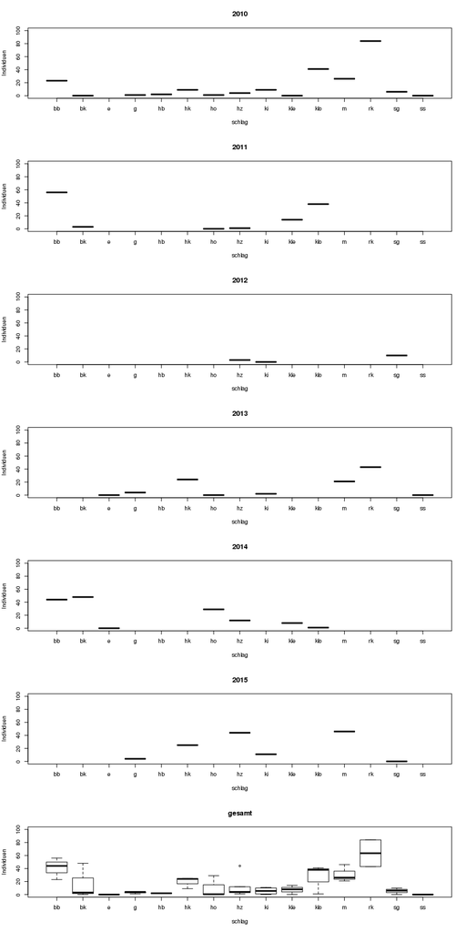

Individuen pro Schlag

```r
par(mfrow=c(7,1))
for(i in 10:15){
    with(
         subset(df.art.schlag, koa == i),
         plot(Individuen ~ schlag,
          main=paste0("20", i),
          ylim=c(0,100)
          )
         )
}
with(df.art.schlag,
     plot(Individuen ~ schlag,
      main="gesamt",
      ylim=c(0,100)
      )
     )
```

```r
v.kasten.schlag <- rep(0, length(df.art.schlag$Individuen))
for(
    i in seq_along(v.kasten.schlag)
    ){
    v.kasten.schlag[i] <- m.schlag[
                       paste0(df.art.schlag$schlag[i]),
                       paste0(df.art.schlag$koa[i])
                       ]
}
df.kasten.art.schlag <- df.art.schlag
df.kasten.art.schlag$Kastenzahl <- v.kasten.schlag
df.kasten.art.schlag$IndProKasten <- with(df.kasten.art.schlag,
                      Individuen / Kastenzahl
                      )
```

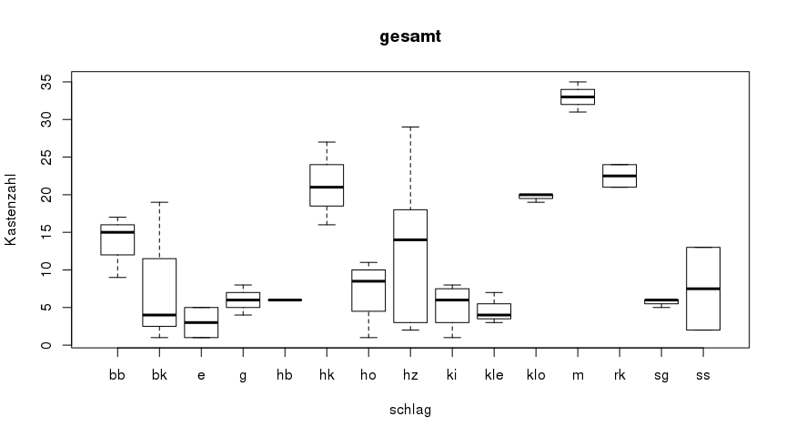

Kästen pro Schlag

```r
with(df.kasten.art.schlag,
         plot(Kastenzahl ~ schlag,
          main="gesamt"
          )
     )
```

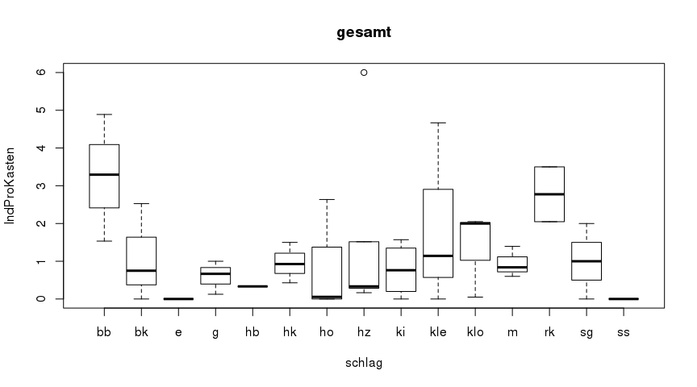

Individuen pro Kasten und Schlag

```r
with(df.kasten.art.schlag,
     plot(IndProKasten ~ schlag,
      main="gesamt"
      )
     )
```

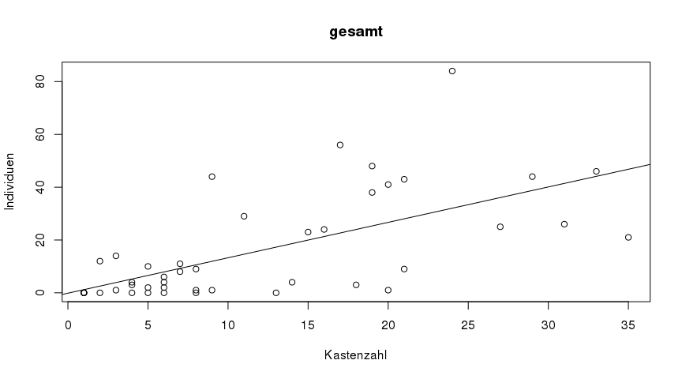

Individuen pro Kasten

```r
with(df.kasten.art.schlag,
     {
         plot(Individuen ~ Kastenzahl,
          main="gesamt"
          )
         abline(lm(Individuen ~ Kastenzahl))
     }
     )
```

Sowohl bei den Quartieren (Tabelle 3) als auch bei den Individuenzahlen (Abb. 2) zeigt sich eine Häufung in einer Reihe von Schlägen, die auf der Karte betrachtet weitgehend zusammenhängen. Bei näherer Betrachtung zeigt sich jedoch, dass dort auch die Kastendichte höher ist (Abb. 3). Die Abbildungen 4 und 5 legen nahe, dass sowohl die Schläge an sich relevant sind, da sich die durchschnittliche Individuenzahl pro Kasten unterscheidet, als auch die Kastendichte.

```r
Model1 <- aov(Individuen ~ Kastenzahl + schlag, data=df.kasten.art.schlag)
```

```r
Table4 <- pander(
         Model1,
         caption="ANOVA: Individuen ~ Kastenzahl + Schlag"
         )
Table4
```

ANOVA: Individuen ~ Kastenzahl + Schlag

|  | Df | Sum Sq | Mean Sq | F value | Pr(>F) |
| --- | --- | --- | --- | --- | --- |
| **Kastenzahl** | 1 | 7038 | 7038 | 41.18 | 5.999e-07 |
| **schlag** | 14 | 5182 | 370.2 | 2.166 | 0.03976 |
| **Residuals** | 28 | 4785 | 170.9 | NA | NA |

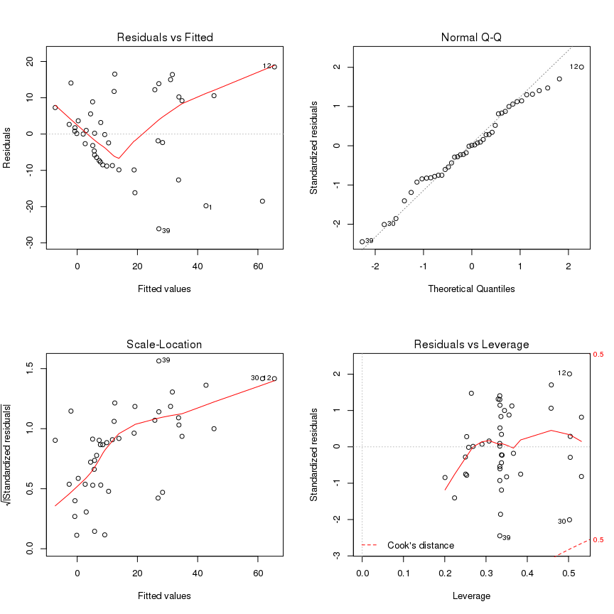

```r
par(mfrow=c(2,2))
plot(Model1)
```

Für den Bereich Rotes Kreuz / Mitterbachl dürften die Offenwasserflächen relevant sein, da diese ein gutes Nahrungsangebot generieren, für die Bereiche südlich der B300 dürfte die Nähe zu diesen relevant sein. Zudem bilden die bevorzugten Bereiche den Kern des Forstes mit seiner größten Ausdehnung.

# 4 Wie steht es um Quantität und Qualität der künstlichen Quartiere?